# Project on Heart Diseases

## Plotting ROCR Curve

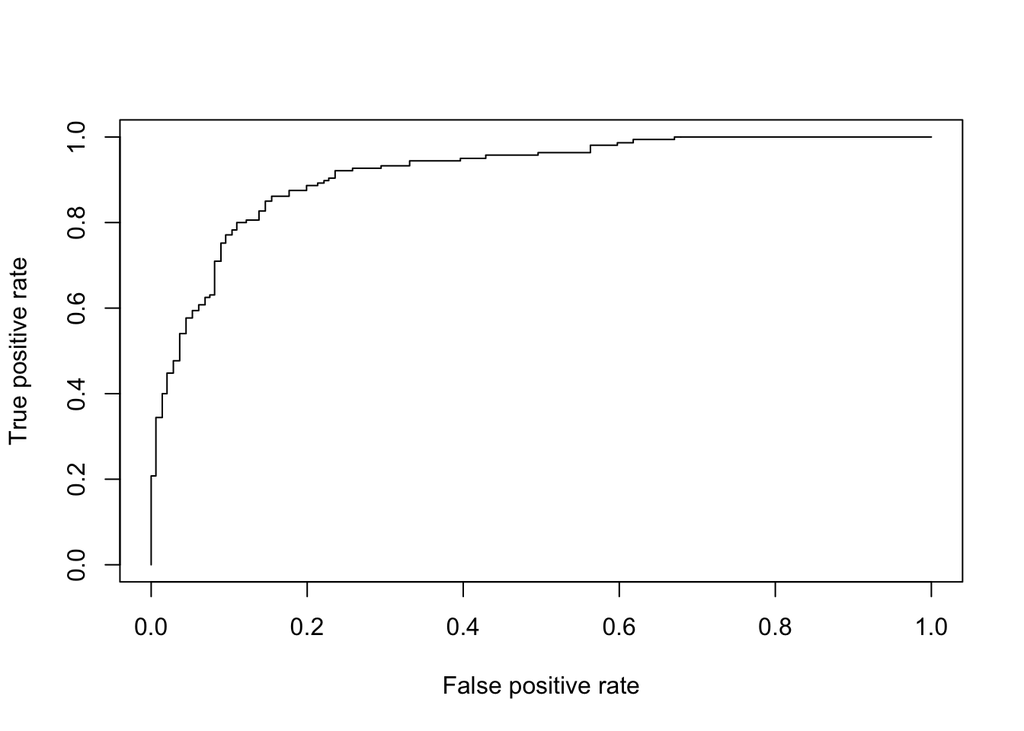

```r
predictTrain=predict(log_model1,type="response")
ROCRpred=prediction(predictTrain, train_data$target)
ROCRperf=performance(ROCRpred,'tpr','fpr')
plot(ROCRperf)
```

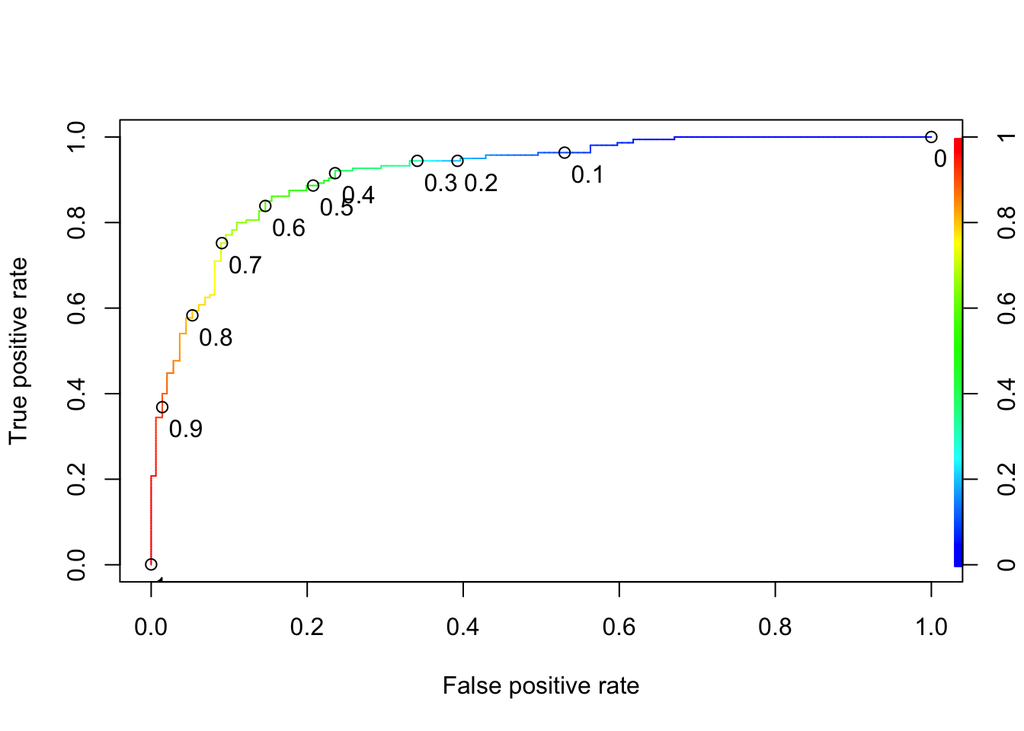

```r
plot(ROCRperf,colorize=TRUE)
plot(ROCRperf, colorize=TRUE, print.cutoffs.at=seq(0,1,by=0.1),
     text.adj=c(-0.2,1.7))
```

## Area under curve

```r
auc = as.numeric(performance(ROCRpred, 'auc')@y.values)
auc
```

```
[1] 0.9154862
```

#### We can see the value of AUC so Higher the AUC, the better the model is at distinguishing between patients with the disease and no disease.The AUC value is 0.91 which means our model is able to distinguish between patients with the disease and no disease with a probability of 0.91,So it is a good value.

## Accuracy

```r
predictTest=predict(log_model1, newdata = test_data, type = "response")
table(test_data$target,predictTest >=0.7)
```

```
    FALSE TRUE
  0   448   44
  1   129  391
```

```r
(448+391)/nrow(test_data)
```

```
[1] 0.8290514
```

#### Logistic regression after removing less significant attributes performed best with an accuracy of testing 82%.

## Conclusion

#### In conclusion, analysis of the heart disease dataset has revealed several important insights. We found that factors such as Chest pain, Sex and ca(number of major vessels) are strongly associated with the presence of heart disease. From our plot, we can infer that non-anginal pain(chest pain) is mostly seen in heart disease patients and Males are more vulnerable to being diagnosed with heart disease than females. Based on the score (82%), the model predicted is good. Factors like smoking, obesity, and a history of heart disease in the family were missing in our dataset which could help in predicting the model. Our visualizations also highlighted the importance of regular exercise on a flat surface and downsloping. Additionally, the sample size is relatively small, which may limit our findings.

#### In future research, it would be beneficial to conduct a larger study with a more diverse population to further validate our results. Additionally, it would be interesting to investigate the potential role of other factors such as stress and sleep in the development of heart disease. Overall, we recommend the importance of maintaining a healthy lifestyle, regular check-ups, early medical attention to chest pain, and public awareness of heart disease(factors) in preventing heart disease.